# BiPOCD_Modeling_2

Sebastian Sauer

21 Juli 2016

```
## [1] "/Users/sebastiansauer/Documents/OneDrive/Forschung/Online_Behavior_Therapy/R_code"
```

# classification (dichotomous)

As we have two outcomes, one dichotomous and one metric, we can both do classification and regression. Let’s look at classification first.

```
## Class of DV:
```

```
##  Factor w/ 2 levels "0","1": 1 2 2 2 2 2 1 1 2 1 ...
```

```
##  Factor w/ 2 levels "0","1": 1 2 2 2 2 1 1 1 1 2 ...
```

```
##  Factor w/ 2 levels "0","1": 2 2 1 2 2 1 1 1 1 1
```

## LM

Let’s fit a linear logistic model. The model showed some problems with factor variables that have sparsely populated levels. Additionally, the ratio of variables to observations is not really nice. We probably will not arrive anywhere with this model.

```
## Class of DV:
```

```
##  Factor w/ 2 levels "0","1": 1 2 2 2 2 2 1 1 2 1 ...
```

```
##  Factor w/ 2 levels "0","1": 1 2 2 2 2 1 1 1 1 2 ...
```

```
##  Factor w/ 2 levels "0","1": 2 2 1 2 2 1 1 1 1 1
```

Classification rate was …bad…? But now look at the variable importance. Note:

> Linear Models: the absolute value of the t–statistic for each model parameter is used.

(From caret help `varimp`.)

| rowname | Overall |
| --- | --- |
| CYBOCS_3m | 0.0001939 |
| ChOCI_R_P_sumimp_PRE | 0.0000761 |
| ChOCI_R_C_sumsym_PRE | 0.0000475 |
| SCAS_S_P_sum_PRE | 0.0000460 |
| EWSASP_sum_PRE | 0.0000450 |

Only top-5 shown.

Let’s look at McFadden’s pseudo R^2.

```r
glmfit1 <- glm(responder_3m_f ~ .,
               data = train,
               family = "binomial",
               control = list(maxit = 50))
pR2(glmfit1)
```

```
##           llh       llhNull            G2      McFadden          r2ML
## -1.583160e-10 -3.118557e+01  6.237114e+01  1.000000e+00  7.815607e-01
##          r2CU
##  1.000000e+00
```

Here, the algorithm tells us that we ran into problems; it may well be that we have too many predictors. MacFadden’s R^2 is 1; appears too good to be true.

Although not undebated among statisticians, let’s try a stepwise regression instead.

## Stepwise LM

[output not shown]

```
## Class of DV:
```

```
##  Factor w/ 2 levels "0","1": 1 2 2 2 2 2 1 1 2 1 ...
```

```
##  Factor w/ 2 levels "0","1": 1 2 2 2 2 1 1 1 1 2 ...
```

```
##  Factor w/ 2 levels "0","1": 2 2 1 2 2 1 1 1 1 1
```

Hm, that’s not so enlightning. Let’s try a different function, `leap::regsubsets`. Let’s do forward selection. Max. nr. of predictors to be included: 10. Note: Here we take the full dataset for model selection. But at least, we use statistics which take the number of predictors into account when choosing the “right” model.

```
## Subset selection object
## Call: regsubsets.formula(responder_3m_f ~ ., data = data_class, nvmax = 10,
##     method = "forward")
## 34 Variables  (and intercept)
##                      Forced in Forced out
## CYBOCS_pre_OBS           FALSE      FALSE
## CYBOCS_pre_COMP          FALSE      FALSE
## CYBOCS_pre_insight       FALSE      FALSE
## CYBOCS_pre_avoid         FALSE      FALSE
## ChOCI_R_C_sumsym_PRE     FALSE      FALSE
## ChOCI_R_C_sumimp_PRE     FALSE      FALSE
## EWSASC_sum_PRE           FALSE      FALSE
## SCAS_S_C_sum_PRE         FALSE      FALSE
## CDI_S_sum_PRE            FALSE      FALSE
## ChOCI_R_P_sumsym_PRE     FALSE      FALSE
## ChOCI_R_P_sumimp_PRE     FALSE      FALSE
## FAS_PR_sum_PRE           FALSE      FALSE
## EWSASP_sum_PRE           FALSE      FALSE
## SCAS_S_P_sum_PRE         FALSE      FALSE
## CYBOCS_3m                FALSE      FALSE
## Depression               FALSE      FALSE
## PanicDisorder            FALSE      FALSE
## SocialPhob               FALSE      FALSE
## SpecificPhob             FALSE      FALSE
## TourettesTics            FALSE      FALSE
## ADHD                     FALSE      FALSE
## GAD                      FALSE      FALSE
## numberdiagnos            FALSE      FALSE
## sexgirl                  FALSE      FALSE
## age                      FALSE      FALSE
## contactSelf-referral     FALSE      FALSE
## distance                 FALSE      FALSE
## medication_yesno         FALSE      FALSE
## CGI_S_pre                FALSE      FALSE
## checking                 FALSE      FALSE
## obsessions               FALSE      FALSE
## contamination            FALSE      FALSE
## symmetry                 FALSE      FALSE
## ID                       FALSE      FALSE
## 1 subsets of each size up to 10
```

[output cut: 85 more lines]

```
## 7  ( 1 )  " "              " "       " "      " "        "*"
## 8  ( 1 )  " "              " "       " "      " "        "*"
## 9  ( 1 )  " "              "*"       " "      " "        "*"
## 10  ( 1 ) " "              "*"       " "      " "        "*"
##           symmetry ID
## 1  ( 1 )  " "      " "
## 2  ( 1 )  " "      " "
## 3  ( 1 )  " "      " "
## 4  ( 1 )  " "      " "
## 5  ( 1 )  " "      " "
## 6  ( 1 )  " "      " "
## 7  ( 1 )  " "      " "
## 8  ( 1 )  " "      " "
## 9  ( 1 )  " "      " "
## 10  ( 1 ) " "      " "
```

So let’s look which variables have been included to the models (starting with 1 predictor to a model with 10 predictors):

```
## ***Model with  1  predictor(s)***
##  (Intercept)   CYBOCS_3m
##  2.22732734 -0.05883144
## ***Model with  2  predictor(s)***
##    (Intercept)     CYBOCS_3m contamination
##    2.35826377   -0.05728243   -0.25821913
## ***Model with  3  predictor(s)***
##     (Intercept) CYBOCS_pre_OBS      CYBOCS_3m  contamination
##     1.89967636     0.04419926    -0.06023701    -0.23424486
## ***Model with  4  predictor(s)***
##       (Intercept)   CYBOCS_pre_OBS SCAS_S_P_sum_PRE        CYBOCS_3m
##       1.84274332       0.03840322       0.01481736      -0.06510302
##    contamination
##      -0.20104637
## ***Model with  5  predictor(s)***
##       (Intercept)   CYBOCS_pre_OBS    CDI_S_sum_PRE SCAS_S_P_sum_PRE
##       1.77118834       0.04591866      -0.03454225       0.02367181
##        CYBOCS_3m    contamination
##      -0.06140731      -0.22860722
## ***Model with  6  predictor(s)***
##           (Intercept)       CYBOCS_pre_OBS        CDI_S_sum_PRE
##           2.03962107           0.05186065          -0.04169694
##     SCAS_S_P_sum_PRE            CYBOCS_3m contactSelf-referral
##           0.02681632          -0.06281985          -0.33681846
##        contamination
##          -0.23363038
## ***Model with  7  predictor(s)***
##           (Intercept)       CYBOCS_pre_OBS ChOCI_R_C_sumsym_PRE
##           2.13574926           0.05677468          -0.01313549
##        CDI_S_sum_PRE     SCAS_S_P_sum_PRE            CYBOCS_3m
##          -0.03500315           0.03179565          -0.06517160
## contactSelf-referral        contamination
##          -0.39840220          -0.19111876
## ***Model with  8  predictor(s)***
##           (Intercept)       CYBOCS_pre_OBS ChOCI_R_C_sumsym_PRE
##          2.213090003          0.042225002         -0.018989876
##       EWSASC_sum_PRE        CDI_S_sum_PRE     SCAS_S_P_sum_PRE
##          0.009073805         -0.036627016          0.032799351
##            CYBOCS_3m contactSelf-referral        contamination
##         -0.067199835         -0.340682049         -0.199266207
## ***Model with  9  predictor(s)***
##           (Intercept)       CYBOCS_pre_OBS ChOCI_R_C_sumsym_PRE
##           2.34067767           0.05215639          -0.01954605
##       EWSASC_sum_PRE        CDI_S_sum_PRE     SCAS_S_P_sum_PRE
##           0.01243197          -0.03867970           0.03471212
##            CYBOCS_3m contactSelf-referral            CGI_S_pre
##          -0.06370208          -0.30868652          -0.10716023
##        contamination
##          -0.19284619
## ***Model with  10  predictor(s)***
##           (Intercept)       CYBOCS_pre_OBS      CYBOCS_pre_COMP
##           2.21175285           0.03555969           0.04299249
## ChOCI_R_C_sumsym_PRE       EWSASC_sum_PRE        CDI_S_sum_PRE
##          -0.02078582           0.01259032          -0.04033728
##     SCAS_S_P_sum_PRE            CYBOCS_3m contactSelf-referral
##           0.03338096          -0.06419860          -0.30696995
##            CGI_S_pre        contamination
##          -0.14910811          -0.20616844
```

Ok, but which model (ie, with what number of predictors) should we choose?

Let’s look at *adjusted* $R^2$.

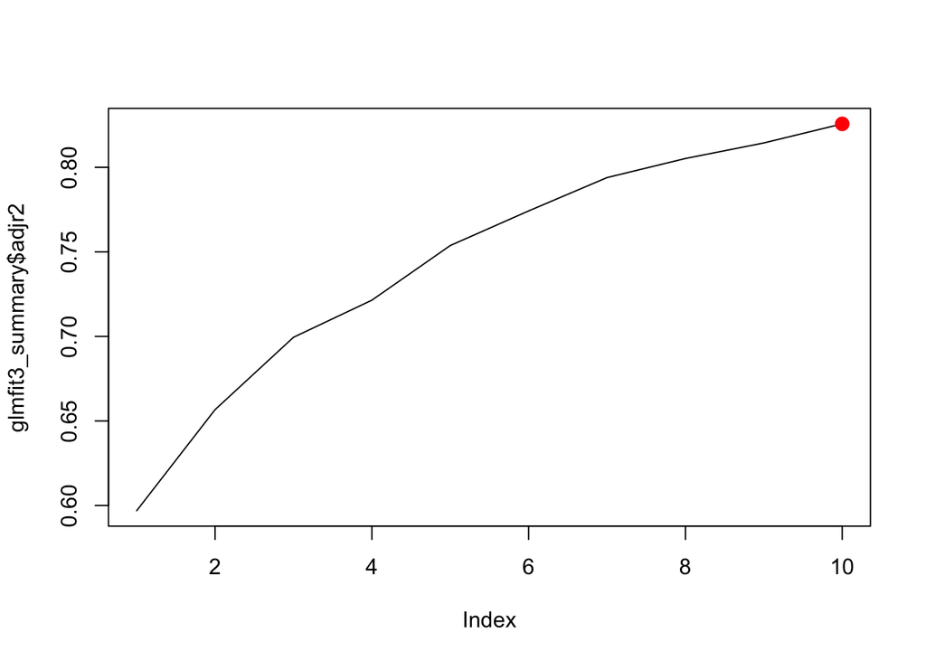

That is, the model suggests 10 predictors to be included.

Let’s look at $BIC$.

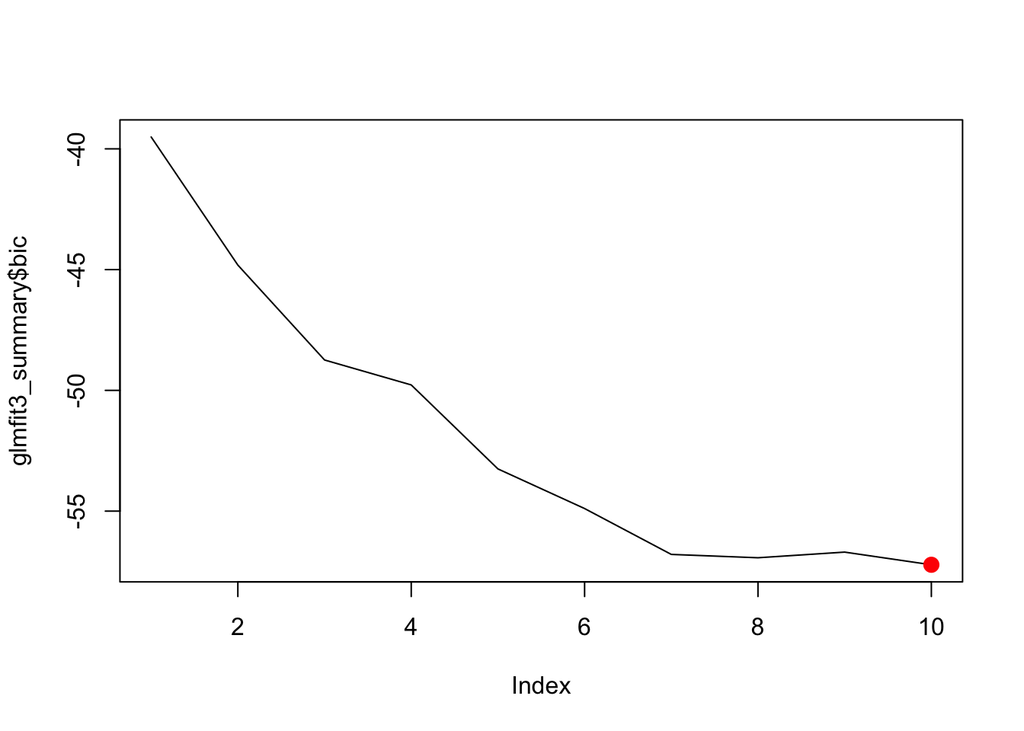

That is, the model suggests 10 predictors to be included.

$BIC$ is more strict in terms of allowing predictors to enter the model. So let’s look finally to $C_p$:

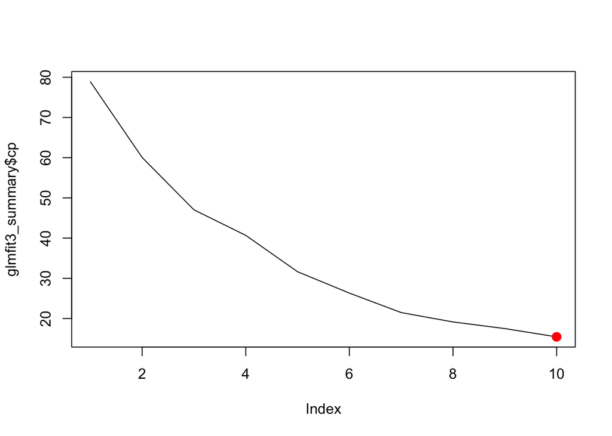

That is, the model suggests 10 predictors to be included.

Ok, so let’s stick to 10 predictors. These are:

```
##       CYBOCS_pre_OBS      CYBOCS_pre_COMP ChOCI_R_C_sumsym_PRE
##           0.03555969           0.04299249          -0.02078582
##       EWSASC_sum_PRE        CDI_S_sum_PRE     SCAS_S_P_sum_PRE
##           0.01259032          -0.04033728           0.03338096
##            CYBOCS_3m contactSelf-referral            CGI_S_pre
##          -0.06419860          -0.30696995          -0.14910811
##        contamination
##          -0.20616844
```

# LM with reduced number of predictors

Ok, now again a linear (logistic) model with the reduced number of predictors. Remember that we work with a train and test sample all the time.

```
##
## Call:
## NULL
##
## Deviance Residuals:
##        Min          1Q      Median          3Q         Max
## -1.234e-05  -2.110e-08  -2.110e-08   2.110e-08   1.603e-05
##
## Coefficients:
##                        Estimate Std. Error z value Pr(>|z|)
## (Intercept)           8.365e+01  6.137e+05   0.000    1.000
## CYBOCS_pre_OBS        7.788e-02  3.382e+04   0.000    1.000
## CYBOCS_pre_COMP       6.702e+00  4.174e+04   0.000    1.000
## ChOCI_R_C_sumsym_PRE -4.607e+00  2.291e+04   0.000    1.000
## EWSASC_sum_PRE        3.110e+00  2.536e+04   0.000    1.000
## CDI_S_sum_PRE        -8.140e+00  3.899e+04   0.000    1.000
## SCAS_S_P_sum_PRE      5.818e+00  1.306e+04   0.000    1.000
## CYBOCS_3m            -8.248e+00  1.299e+04  -0.001    0.999
## CGI_S_pre            -1.917e+01  9.744e+04   0.000    1.000
## contamination        -2.512e+01  2.557e+05   0.000    1.000
##
## (Dispersion parameter for binomial family taken to be 1)
##
##     Null deviance: 5.8466e+01  on 42  degrees of freedom
## Residual deviance: 9.8609e-10  on 33  degrees of freedom
## AIC: 20
##
## Number of Fisher Scoring iterations: 25
```

| predictors | Estimate | Std. Error | z value | Pr(>\|z\|) |
| --- | --- | --- | --- | --- |
| (Intercept) | 83.6516838 | 613744.85 | 0.0001363 | 0.9998913 |
| CYBOCS_pre_OBS | 0.0778802 | 33818.70 | 0.0000023 | 0.9999982 |
| CYBOCS_pre_COMP | 6.7019260 | 41737.77 | 0.0001606 | 0.9998719 |
| ChOCI_R_C_sumsym_PRE | -4.6069406 | 22907.34 | -0.0002011 | 0.9998395 |
| EWSASC_sum_PRE | 3.1101002 | 25356.08 | 0.0001227 | 0.9999021 |
| CDI_S_sum_PRE | -8.1397456 | 38991.07 | -0.0002088 | 0.9998334 |
| SCAS_S_P_sum_PRE | 5.8184300 | 13058.41 | 0.0004456 | 0.9996445 |
| CYBOCS_3m | -8.2477085 | 12992.82 | -0.0006348 | 0.9994935 |
| CGI_S_pre | -19.1734141 | 97441.12 | -0.0001968 | 0.9998430 |
| contamination | -25.1236067 | 255650.41 | -0.0000983 | 0.9999216 |

Accuracy as measured by Cohen’s Kappa in **train** set is

```
## [1] 1
```

```
## Confusion Matrix and Statistics
##
##           Reference
## Prediction 0 1
##          0 6 0
##          1 0 4
##
##                Accuracy : 1
##                  95% CI : (0.6915, 1)
##     No Information Rate : 0.6
##     P-Value [Acc > NIR] : 0.006047
##
##                   Kappa : 1
##  Mcnemar's Test P-Value : NA
##
##             Sensitivity : 1.0
##             Specificity : 1.0
##          Pos Pred Value : 1.0
##          Neg Pred Value : 1.0
##              Prevalence : 0.6
##          Detection Rate : 0.6
##    Detection Prevalence : 0.6
##       Balanced Accuracy : 1.0
##
##        'Positive' Class : 0
##
```

Ok, interesting, we see that not many variables are statistically significant (p<.05) now:

[output not shown]